# Progress Memo 1

### Potential data issues

There are no data issues, missingness issues, or skewness with the target variable, and the distribution of TRUE and FALSE values is roughly evenly split. Interestingly, stacked bar analyses suggest that the majority of songs that are skipped (`skip_2`) typically were also *skipped to*, whereas the songs that were not skipped were typically played from another song being played through. In other words, if the user skipped a song to get to the current song (`hist_user_behavior_reason_start` == “fwdbtn”), then the current song is more likely to be skipped too.

Potential transformations could involve the auditory feature variables that are measured from 0.0 to 1.0, like acousticness and danceability. These variables could be inverse-log transformed so the differences between tracks are more meaningful.

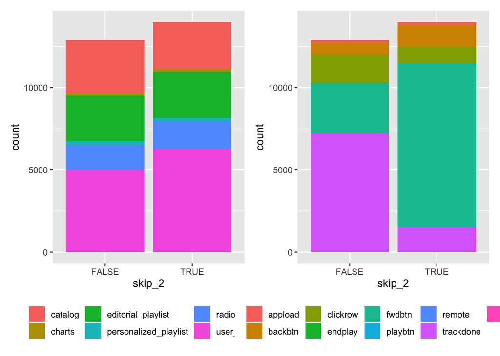

```r
## split data ----
set.seed(1104)

# initial split
spotify_split <- spotify_data |>
  group_initial_split(group = "session_id", prop = 0.8)

spotify_train <- spotify_split |> training()
spotify_test <- spotify_split |> testing()

# split for eda
spotify_split_eda <- spotify_train |>
  group_initial_split(group = "session_id", prop = 0.2)

spotify_eda <- spotify_split_eda |> training()

plot_stacked_bar <- function(data, x_variable, fill_variable) {
  ggplot(data, aes({{x_variable}}, fill = {{fill_variable}})) +
    geom_bar(position = "stack") +
    theme(legend.position = "bottom", legend.title = element_blank())
}

plot1 <- spotify_eda |> plot_stacked_bar(skip_2, context_type)
plot2 <- spotify_eda |> plot_stacked_bar(skip_2, hist_user_behavior_reason_start)
plot3 <- spotify_eda |> plot_stacked_bar(skip_2, hist_user_behavior_reason_end)
plot4 <- spotify_eda |> plot_stacked_bar(skip_2, key)
plot5 <- spotify_eda |> plot_stacked_bar(skip_2, mode)
plot6 <- spotify_eda |> plot_stacked_bar(skip_2, time_signature)

(plot1 + plot2)
```

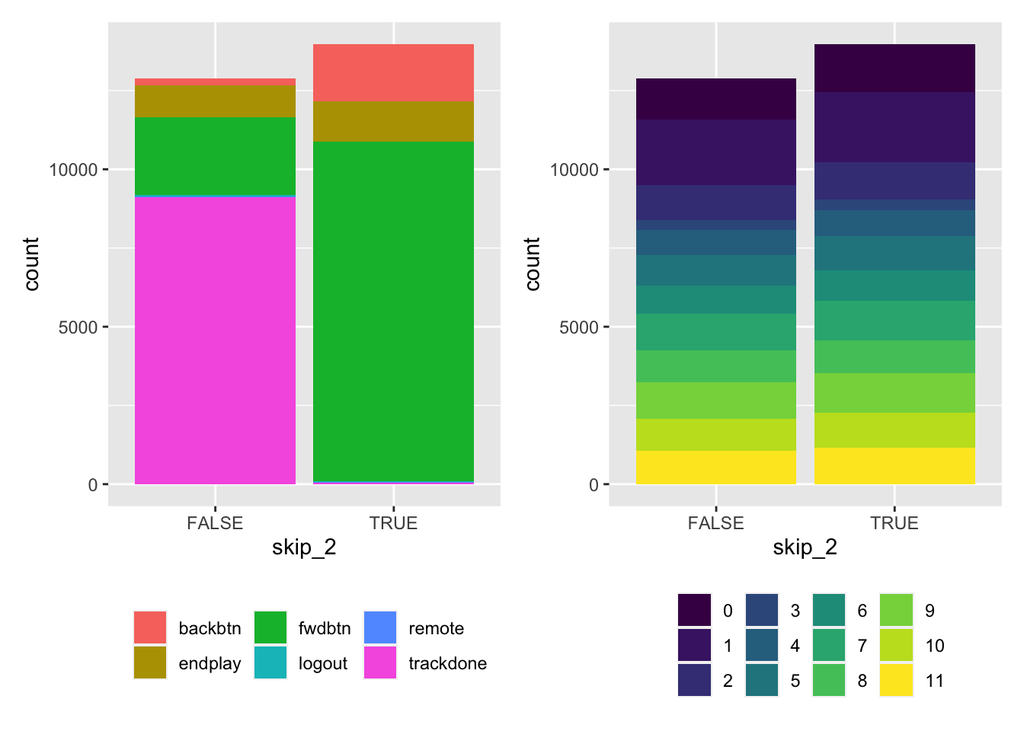

```r
(plot3 + plot4)
```

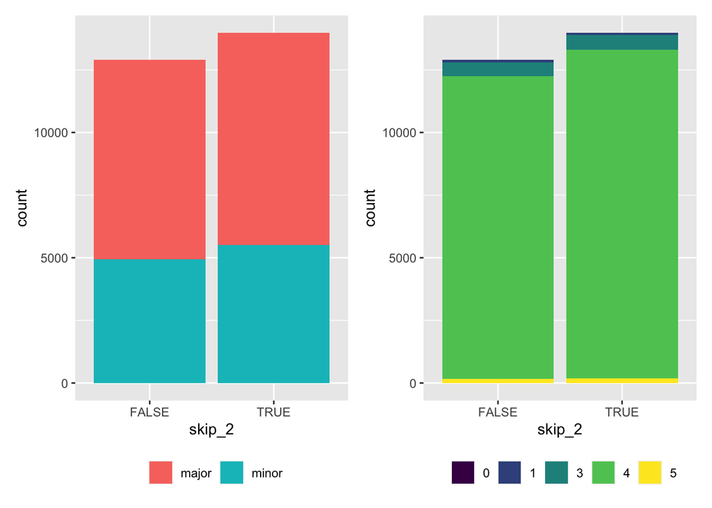

```r
(plot5 + plot6)
```